# geodata-trip-origin-study

**Overview:**  
To find the total number of trips that originated from within the study area, we will use the census tract and study area shape files to find what share of each census tract lies within the study area. We will then multiply this share by the trip origin counts to extrapolate the share of trips from each tract that lie within the study area. For example, a census tract that is wholly within the study area will have all trips included in the estimate; a tract that is 50% in the study area will have 50% of its trips included. **This leads to an estimate of 63,943 trip origins within the study area.**

This methodology assumes that the distribution of trip origins within a census tract is relatively uniform. The Census Bureau defines a tract as a "small...statistical subdivision...between 1,200 and 8,000 people". Given the fairly small size of tracts, this assumption of uniformity seems reasonable. However, it is possible that tracts with heavily split land use types (e.g. residential v. commercial), highly varied densities, or populations spread across large geographic areas could see divergent patterns. One possible way of overcoming this would be to weigh the distribution of trips within a tract by the count of trips in surrounding tracts. However, the computational complexity of this would rise rapidly and pose a challenge.  
**Methodology:**  
**Extracting the Data:**

- The data are provided as shape files and a csv file. Pandas and Geopandas are effective tools for extracting, transforming, and analyzing these data.

**Transforming the Data:**

- We want to find the overlap between the census tracts and the study area. Geopandas's overlay function can be used to find this. Geopandas will automatically calculate the area of these new geometries. We'll save this dataframe as *overlap*.
- We'll merge the *overlap* dataframe into the census tract dataframe to bring together the overlap and original areas. From these, we'll calculate the size of the overlap area as a percent of the original census tract area.
  - Using a "right" merge will limit the merged dataset to just those census tracts that lie wholly or partially within the study area. This will shrink the dataset and improve the performance of subsequent operations. However, it will limit the availability of data in this dataframe for later analysis.
- In OriginTripCounts, we'll format the GEOID field so that it can be used as a key to merge with the combined area data. We'll merge these data and multiply the count of trips by the area shares, computed above, to give us the share of trips originating in the study area for each tract.
- To find the total number of trips within the study area, we'll sum the tract-level counts.

**Optional Plots:**  
I created a few plots to help visualize the data. These show the count of trip origins by census tract, the share of each census tract in the study area, and the estimated number of trips originating within the study area for each census tract.  
**Performance note: I prioritized performance of the trip count estimation. As a result, census tracts outside the study area were excluded in the dataframe generated for the count estimation analysis. To create these optional plots, I needed to duplicate some steps performed in the earlier analysis with all census tracts, resulting in some extra computes.**

**Scaling Analysis:**  
Given the small data sizes involved in this particular analysis, performance is not a major concern. However, it is easy to imagine a similar analysis being desired over many more census tracts and larger or more numerous study areas. In this case, techniques to limit the scope of data could be used, such as immediately ruling out census tracts in states outside the study area. Alternatively, new analytical tools could be used. Postgis can provide some performance improvements over Geopandas. Cloud computing and parallelism, including Hadoop and Spark, could be used for large computational loads.

```python
import pandas as pd
import geopandas as gpd
```

```python
def extractData(filePath):
    try:
        originTripCounts = pd.read_csv(filePath+'OriginTripCounts.csv',dtype={'tract_id':str})
        studyAreaShape = gpd.read_file(filePath+'StudyArea',dtype={'GEOID':str})
        censusTractShape = gpd.read_file(filePath+'Tracts')
        return originTripCounts, studyAreaShape, censusTractShape
    except Exception as e:
        print('Data Extraction Error')
        print(str(e))
```

```python
def transformData(originTripCounts, studyAreaShape, censusTractShape):
    # Data Validation Note: Provided area values (area_sq_m) differ from generated (geometry.area) due to rounding
    #     censusTractShape['tractArea'] = censusTractShape.geometry.area
    #     censusTractShape['areaCompare'] = abs(censusTractShape['tractArea']-censusTractShape['area_sq_m'])
    #     print(max(censusTractShape['areaCompare']))

    # Finding overlapping geometries between Study area and Census tracts
    overlap = gpd.overlay(censusTractShape, studyAreaShape, how='intersection')
    overlap['overlapArea'] = overlap.geometry.area
    overlap = overlap[['GEOID','overlapArea']]

    # Preparing trips data for merge
    originTripCounts['GEOID'] = originTripCounts['tract_id'].str.split(pat=":", expand=True)[4]
    originTripCounts = originTripCounts.drop(['tract_id'],axis=1)

    # Merging overlap and census tract data
    # Performance Note: By limiting the data to only census tracts in the overlap,
    # we reduce the size of our data and improve runtime of subsequent operations
    catchmentArea = censusTractShape.merge(overlap, on='GEOID', how='right')
    catchmentArea = catchmentArea.merge(originTripCounts, on='GEOID', how='left')
    catchmentArea['catchmentTrips'] = catchmentArea['overlapArea']/catchmentArea['area_sq_m']*catchmentArea['origin_trips']

    return catchmentArea
```

```python
# Optional: Data visualizations to help understand data
# Performance note: I prioritized performance of the trip count estimation. As a result, census tracts outside
# the study area were excluded in the dataframe generated for the count estimation analysis. To create these
# optional plots, I needed to duplicate some steps performed in the earlier analysis with all census tracts,
# resulting in some extra computes.

def dataVisualizations(originTripCounts, studyAreaShape, censusTractShape):
    # Finding overlapping geometries between Study area and Census tracts
    overlap = gpd.overlay(censusTractShape, studyAreaShape, how='intersection')
    overlap['overlapArea'] = overlap.geometry.area
    overlap = overlap[['GEOID','overlapArea']]

    # Preparing trips data for merge
    originTripCounts['GEOID'] = originTripCounts['tract_id'].str.split(pat=":", expand=True)[4]
    originTripCounts = originTripCounts.drop(['tract_id'],axis=1)

    # Merging overlap and census tract data
    mergedData = censusTractShape.merge(overlap, on='GEOID', how='left')
    mergedData = mergedData.merge(originTripCounts, on='GEOID', how='left')
    mergedData['tractCatchmentShare'] = mergedData['overlapArea']/mergedData['area_sq_m']
    mergedData['tractCatchmentShare'] = mergedData['tractCatchmentShare'].fillna(value=0)
    mergedData['catchmentTrips'] = mergedData['tractCatchmentShare']*mergedData['origin_trips']

    # Generating Count of Trips by Census Tract Plot
    tripsByTract = mergedData.plot(
        figsize=(10,10),
        edgecolor='darkgrey',
        column='origin_trips',
        legend=True,
        legend_kwds={'label': "Count of Trip Origins"}
    )
    tripsByTract.set_title("Trip Origins by Census Tract", fontsize=20)
    tripsByTract.set_axis_off()

    # Generating Share of Census Tract in Study Area Plot
    shareTractInStudy = mergedData.plot(
        figsize=(10,10),
        edgecolor='darkgrey',
        column='tractCatchmentShare',
        legend=True,
        legend_kwds={'label': "Share of Census Tract Area"}
    )
    studyAreaShape.boundary.plot(ax=shareTractInStudy, edgecolor='black')
    shareTractInStudy.set_title("Area Share of Census Tracts in Study Area", fontsize=20)
    shareTractInStudy.set_axis_off()

    # Generating Count of Trip Orgins in Study Area by Census Tract Plot
    tripsInStudy = mergedData.plot(
        figsize=(10,10),
        edgecolor='darkgrey',
        column='catchmentTrips',
        legend=True,
        legend_kwds={'label': "Count of Trip Origins in Study Area"}
    )
    studyAreaShape.boundary.plot(ax=tripsInStudy, edgecolor='black')
    tripsInStudy.set_title("Trip Orgins in Study Area by Census Tract", fontsize=20)
    tripsInStudy.set_axis_off()
```

```python
# Executing analysis
originTripCounts, studyAreaShape, censusTractShape = extractData('GeoEngTestData/')
catchmentArea = transformData(originTripCounts, studyAreaShape, censusTractShape)

totalTrips = round(sum(catchmentArea['catchmentTrips']))
print('Total number of trips that originated within the study area: \n',
      f'{totalTrips:,}')
```

```
Total number of trips that originated within the study area:
 63,943
```

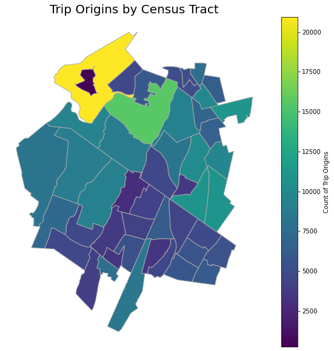

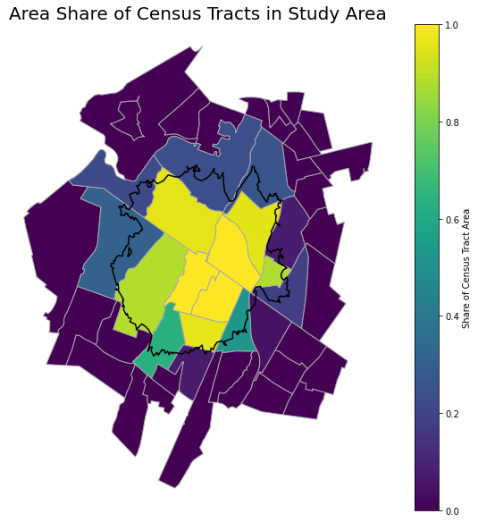

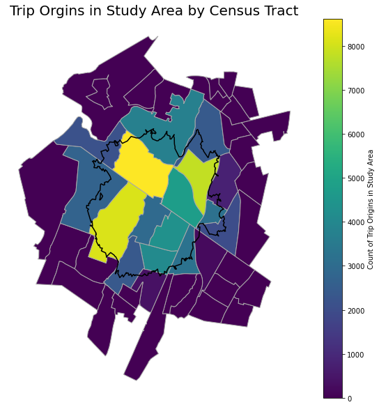

```python
# Generating optional plots
dataVisualizations(originTripCounts, studyAreaShape, censusTractShape)
```